# Regression Analysis of IMDB 5000 Movies Datasets

```r
full1<-lm(movie.train$imdb_score~movie.train$num_voted_users+movie.train$num_critic_for_reviews+movie.train$num_user_for_reviews+movie.train$duration+movie.train$facenumber_in_poster+movie.train$gross+movie.train$movie_facebook_likes+movie.train$director_facebook_likes+movie.train$cast_total_facebook_likes+movie.train$budget+movie.train$title_year+movie.train$num_voted_users:movie.train$num_critic_for_reviews+movie.train$num_voted_users:movie.train$duration+movie.train$num_voted_users:movie.train$title_year+movie.train$num_critic_for_reviews:movie.train$num_user_for_reviews+movie.train$duration:movie.train$title_year+movie.train$gross:movie.train$budget+movie.train$cast_total_facebook_likes:movie.train$title_year+movie.train$budget:movie.train$title_year)
summary(full1)
```

```
Call:
lm(formula = movie.train$imdb_score ~ movie.train$num_voted_users +
    movie.train$num_critic_for_reviews + movie.train$num_user_for_reviews +
    movie.train$duration + movie.train$facenumber_in_poster +
    movie.train$gross + movie.train$movie_facebook_likes + movie.train$director_facebook_likes +
    movie.train$cast_total_facebook_likes + movie.train$budget +
    movie.train$title_year + movie.train$num_voted_users:movie.train$num_critic_for_reviews +
    movie.train$num_voted_users:movie.train$duration + movie.train$num_voted_users:movie.train$title_year +
    movie.train$num_critic_for_reviews:movie.train$num_user_for_reviews +
    movie.train$duration:movie.train$title_year + movie.train$gross:movie.train$budget +
    movie.train$cast_total_facebook_likes:movie.train$title_year +
    movie.train$budget:movie.train$title_year)

Residuals:
    Min      1Q  Median      3Q     Max
-4.4855 -0.3870  0.0531  0.4961  2.5529

Coefficients:
                                                                      Estimate Std. Error
(Intercept)                                                          1.056e+02  1.342e+01
movie.train$num_voted_users                                         -5.604e-05  2.715e-05
movie.train$num_critic_for_reviews                                   3.207e-03  2.478e-04
movie.train$num_user_for_reviews                                    -8.074e-04  1.336e-04
movie.train$duration                                                -4.337e-01  1.080e-01
movie.train$facenumber_in_poster                                    -1.986e-02  6.926e-03
movie.train$gross                                                   -1.411e-09  4.331e-10
movie.train$movie_facebook_likes                                    -8.879e-07  1.083e-06
movie.train$director_facebook_likes                                  1.122e-05  4.583e-06
movie.train$cast_total_facebook_likes                                1.208e-03  2.742e-04
movie.train$budget                                                  -4.164e-07  1.194e-07
movie.train$title_year                                              -5.076e-02  6.711e-03
movie.train$num_voted_users:movie.train$num_critic_for_reviews      -7.324e-09  1.106e-09
movie.train$num_voted_users:movie.train$duration                    -3.086e-08  3.549e-09
movie.train$num_voted_users:movie.train$title_year                   3.284e-08  1.359e-08
movie.train$num_critic_for_reviews:movie.train$num_user_for_reviews  7.015e-07  3.843e-07
movie.train$duration:movie.train$title_year                          2.254e-04  5.406e-05
movie.train$gross:movie.train$budget                                 1.718e-17  3.305e-18
movie.train$cast_total_facebook_likes:movie.train$title_year        -6.018e-07  1.367e-07
movie.train$budget:movie.train$title_year                            2.041e-10  5.951e-11
                                                                    t value Pr(>|t|)
```

[output cut: 11 more lines]

```
movie.train$title_year                                               -7.564 5.34e-14 ***
movie.train$num_voted_users:movie.train$num_critic_for_reviews       -6.622 4.26e-11 ***
movie.train$num_voted_users:movie.train$duration                     -8.695  < 2e-16 ***
movie.train$num_voted_users:movie.train$title_year                    2.417 0.015707 *
movie.train$num_critic_for_reviews:movie.train$num_user_for_reviews   1.825 0.068074 .
movie.train$duration:movie.train$title_year                           4.169 3.16e-05 ***
movie.train$gross:movie.train$budget                                  5.196 2.19e-07 ***
movie.train$cast_total_facebook_likes:movie.train$title_year         -4.402 1.11e-05 ***
movie.train$budget:movie.train$title_year                             3.429 0.000615 ***
---
Signif. codes:  0 ‘***’ 0.001 ‘**’ 0.01 ‘*’ 0.05 ‘.’ 0.1 ‘ ’ 1

Residual standard error: 0.7602 on 2685 degrees of freedom
Multiple R-squared:  0.4886,    Adjusted R-squared:  0.4849
F-statistic:   135 on 19 and 2685 DF,  p-value: < 2.2e-16
```

```r
step(null,scope = list(lower=null,upper=full1,direction = 'forward'))
```

```
Start:  AIC=312.76
movie.train$imdb_score ~ 1

                                        Df Sum of Sq    RSS     AIC
+ movie.train$num_voted_users            1    880.03 2154.3 -611.77
+ movie.train$duration                   1    517.81 2516.5 -191.39
+ movie.train$num_critic_for_reviews     1    454.31 2580.0 -123.98
+ movie.train$num_user_for_reviews       1    417.91 2616.4  -86.08
+ movie.train$movie_facebook_likes       1    287.06 2747.2   45.92
+ movie.train$gross                      1    267.93 2766.4   64.69
+ movie.train$director_facebook_likes    1    168.13 2866.2  160.56
+ movie.train$cast_total_facebook_likes  1     75.20 2959.1  246.87
+ movie.train$title_year                 1     47.52 2986.8  272.06
+ movie.train$budget                     1     24.93 3009.4  292.44
+ movie.train$facenumber_in_poster       1     13.52 3020.8  302.68
<none>                                               3034.3  312.76

Step:  AIC=-611.77
movie.train$imdb_score ~ movie.train$num_voted_users

                                        Df Sum of Sq    RSS     AIC
+ movie.train$duration                   1    167.37 1986.9 -828.54
+ movie.train$title_year                 1     59.06 2095.2 -684.97
+ movie.train$budget                     1     47.48 2106.8 -670.06
+ movie.train$num_user_for_reviews       1     21.33 2133.0 -636.69
+ movie.train$num_critic_for_reviews     1     20.97 2133.3 -636.23
+ movie.train$director_facebook_likes    1     15.14 2139.1 -628.85
+ movie.train$gross                      1      8.37 2145.9 -620.30
+ movie.train$facenumber_in_poster       1      5.27 2149.0 -616.39
+ movie.train$movie_facebook_likes       1      3.30 2151.0 -613.91
+ movie.train$cast_total_facebook_likes  1      2.10 2152.2 -612.41
<none>                                               2154.3 -611.77
- movie.train$num_voted_users            1    880.03 3034.3  312.76

Step:  AIC=-828.54
movie.train$imdb_score ~ movie.train$num_voted_users + movie.train$duration

                                                   Df Sum of Sq    RSS      AIC
+ movie.train$num_voted_users:movie.train$duration  1    125.49 1861.4 -1003.02
+ movie.train$budget                                1     79.54 1907.4  -937.05
```

[output cut: 566 more lines]

```
                                                         -1.896e-06
                   movie.train$num_voted_users:movie.train$duration
                                                         -2.743e-08
     movie.train$num_voted_users:movie.train$num_critic_for_reviews
                                                         -6.714e-09
                        movie.train$duration:movie.train$title_year
                                                          2.323e-04
                          movie.train$budget:movie.train$title_year
                                                          2.596e-10
movie.train$num_critic_for_reviews:movie.train$num_user_for_reviews
                                                          9.639e-07
                 movie.train$num_voted_users:movie.train$title_year
                                                          3.935e-08
       movie.train$title_year:movie.train$cast_total_facebook_likes
                                                         -5.947e-07
```

Choosen: step 1415 #movie.train$imdb_score ~ movie.train$num_voted_users + movie.train$duration + # movie.train$budget + movie.train$num_critic_for_reviews + # movie.train$title_year + movie.train$num_user_for_reviews + # movie.train$facenumber_in_poster + movie.train$num_voted_users:movie.train$duration + # movie.train$num_voted_users:movie.train$num_critic_for_reviews + # movie.train$duration:movie.train$title_year + movie.train$budget:movie.train$title_year + # movie.train$num_critic_for_reviews:movie.train$num_user_for_reviews + # movie.train$num_voted_users:movie.train$title_year

# After normaliza: (no improvement )

Step: AIC=-12451.54 #movie.train$imdb_score ~ movie.train$num_voted_users + movie.train$duration + # movie.train$budget + movie.train$num_critic_for_reviews + # movie.train$title_year + movie.train$num_user_for_reviews + # movie.train$facenumber_in_poster + movie.train$num_voted_users:movie.train$duration + # movie.train$num_voted_users:movie.train$num_critic_for_reviews + # movie.train$duration:movie.train$title_year + movie.train$budget:movie.train$title_year

```r
lm.fit1=lm(
movie.train$imdb_score ~ movie.train$num_voted_users + movie.train$duration +
    movie.train$budget + movie.train$num_critic_for_reviews +
    movie.train$title_year + movie.train$num_user_for_reviews +
    movie.train$facenumber_in_poster + movie.train$num_voted_users:movie.train$duration +
    movie.train$num_voted_users:movie.train$num_critic_for_reviews +
    movie.train$duration:movie.train$title_year + movie.train$budget:movie.train$title_year +
    movie.train$num_critic_for_reviews:movie.train$num_user_for_reviews +
    movie.train$num_voted_users:movie.train$title_year)
 summary(lm.fit1)
```

```
Call:
lm(formula = movie.train$imdb_score ~ movie.train$num_voted_users +
    movie.train$duration + movie.train$budget + movie.train$num_critic_for_reviews +
    movie.train$title_year + movie.train$num_user_for_reviews +
    movie.train$facenumber_in_poster + movie.train$num_voted_users:movie.train$duration +
    movie.train$num_voted_users:movie.train$num_critic_for_reviews +
    movie.train$duration:movie.train$title_year + movie.train$budget:movie.train$title_year +
    movie.train$num_critic_for_reviews:movie.train$num_user_for_reviews +
    movie.train$num_voted_users:movie.train$title_year)

Residuals:
    Min      1Q  Median      3Q     Max
-4.5666 -0.3997  0.0577  0.5153  2.6091

Coefficients:
                                                                      Estimate Std. Error
(Intercept)                                                          1.151e+02  1.336e+01
movie.train$num_voted_users                                         -5.367e-05  2.702e-05
movie.train$duration                                                -4.580e-01  1.084e-01
movie.train$budget                                                  -3.590e-07  1.123e-07
movie.train$num_critic_for_reviews                                   2.851e-03  2.353e-04
movie.train$title_year                                              -5.547e-02  6.684e-03
movie.train$num_user_for_reviews                                    -8.435e-04  1.327e-04
movie.train$facenumber_in_poster                                    -2.074e-02  6.960e-03
movie.train$num_voted_users:movie.train$duration                    -2.758e-08  3.502e-09
movie.train$num_voted_users:movie.train$num_critic_for_reviews      -7.167e-09  1.101e-09
movie.train$duration:movie.train$title_year                          2.374e-04  5.425e-05
movie.train$budget:movie.train$title_year                            1.763e-10  5.592e-11
movie.train$num_critic_for_reviews:movie.train$num_user_for_reviews  1.018e-06  3.809e-07
movie.train$num_voted_users:movie.train$title_year                   3.144e-08  1.353e-08
                                                                    t value Pr(>|t|)
(Intercept)                                                           8.609  < 2e-16 ***
movie.train$num_voted_users                                          -1.986  0.04710 *
movie.train$duration                                                 -4.227 2.45e-05 ***
movie.train$budget                                                   -3.197  0.00140 **
movie.train$num_critic_for_reviews                                   12.117  < 2e-16 ***
movie.train$title_year                                               -8.298  < 2e-16 ***
movie.train$num_user_for_reviews                                     -6.358 2.40e-10 ***
movie.train$facenumber_in_poster                                     -2.980  0.00291 **
movie.train$num_voted_users:movie.train$duration                     -7.876 4.88e-15 ***
movie.train$num_voted_users:movie.train$num_critic_for_reviews       -6.509 8.99e-11 ***
movie.train$duration:movie.train$title_year                           4.376 1.25e-05 ***
movie.train$budget:movie.train$title_year                             3.154  0.00163 **
movie.train$num_critic_for_reviews:movie.train$num_user_for_reviews   2.672  0.00759 **
movie.train$num_voted_users:movie.train$title_year                    2.324  0.02021 *
---
Signif. codes:  0 ‘***’ 0.001 ‘**’ 0.01 ‘*’ 0.05 ‘.’ 0.1 ‘ ’ 1

Residual standard error: 0.7678 on 2691 degrees of freedom
Multiple R-squared:  0.4772,    Adjusted R-squared:  0.4746
F-statistic: 188.9 on 13 and 2691 DF,  p-value: < 2.2e-16
```

```r
lm.fit1<-lm(movie.train$imdb_score ~ movie.train$num_voted_users + movie.train$duration +
    movie.train$budget + movie.train$num_critic_for_reviews +
    movie.train$title_year + movie.train$num_user_for_reviews +
    movie.train$facenumber_in_poster + movie.train$num_voted_users:movie.train$duration +
    movie.train$num_voted_users:movie.train$num_critic_for_reviews +
    movie.train$duration:movie.train$title_year + movie.train$budget:movie.train$title_year)
summary(lm.fit1)
```

[output not shown]

```
                                   Test stat Pr(>|t|)
movie.train$num_voted_users           -3.107    0.002
movie.train$duration                  -4.308    0.000
movie.train$budget                     4.660    0.000
movie.train$num_critic_for_reviews    -5.993    0.000
movie.train$title_year                -2.740    0.006
movie.train$num_user_for_reviews       3.241    0.001
movie.train$facenumber_in_poster       0.946    0.344
Tukey test                           -13.225    0.000
```

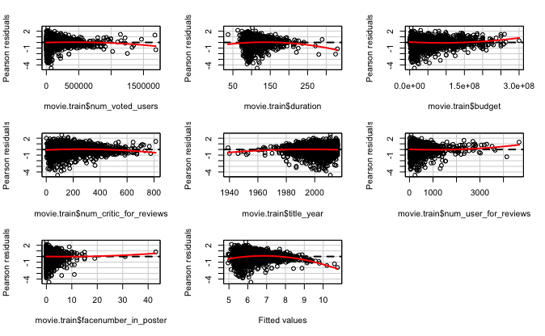

```r
library(car)
residualPlots(lm.fit1)
```

```r
lm.fit2<- lm(movie.train$imdb_score ~ poly(movie.train$num_voted_users,2) + poly(movie.train$duration,2) +
    poly(movie.train$budget,2) + poly(movie.train$num_critic_for_reviews,2) +
    poly(movie.train$title_year,2) + poly(movie.train$num_user_for_reviews,2) +
    poly(movie.train$facenumber_in_poster,2) + movie.train$num_voted_users:movie.train$duration +
    movie.train$num_voted_users:movie.train$num_critic_for_reviews +
    movie.train$duration:movie.train$title_year + movie.train$budget:movie.train$title_year +
    movie.train$num_critic_for_reviews:movie.train$num_user_for_reviews +
    movie.train$num_voted_users:movie.train$title_year)
summary(lm.fit2)
```

```
Call:
lm(formula = movie.train$imdb_score ~ poly(movie.train$num_voted_users,
    2) + poly(movie.train$duration, 2) + poly(movie.train$budget,
    2) + poly(movie.train$num_critic_for_reviews, 2) + poly(movie.train$title_year,
    2) + poly(movie.train$num_user_for_reviews, 2) + poly(movie.train$facenumber_in_poster,
    2) + movie.train$num_voted_users:movie.train$duration + movie.train$num_voted_users:movie.train$num_critic_for_reviews +
    movie.train$duration:movie.train$title_year + movie.train$budget:movie.train$title_year +
    movie.train$num_critic_for_reviews:movie.train$num_user_for_reviews +
    movie.train$num_voted_users:movie.train$title_year)

Residuals:
    Min      1Q  Median      3Q     Max
-4.5070 -0.3779  0.0500  0.4884  2.4867

Coefficients:
                                                                      Estimate Std. Error
(Intercept)                                                         -3.216e+01  1.416e+01
poly(movie.train$num_voted_users, 2)1                               -1.361e+02  2.325e+02
poly(movie.train$num_voted_users, 2)2                               -9.636e+00  1.358e+00
poly(movie.train$duration, 2)1                                      -1.312e+02  1.474e+02
poly(movie.train$duration, 2)2                                      -4.186e+00  8.440e-01
poly(movie.train$budget, 2)1                                        -1.129e+03  3.007e+02
poly(movie.train$budget, 2)2                                         4.286e+00  8.700e-01
poly(movie.train$num_critic_for_reviews, 2)1                         1.591e+01  2.063e+00
poly(movie.train$num_critic_for_reviews, 2)2                        -9.123e+00  1.351e+00
poly(movie.train$title_year, 2)1                                    -1.908e+01  3.523e+00
poly(movie.train$title_year, 2)2                                    -5.046e+00  1.034e+00
poly(movie.train$num_user_for_reviews, 2)1                          -1.872e+01  3.275e+00
poly(movie.train$num_user_for_reviews, 2)2                           8.387e+00  1.295e+00
poly(movie.train$facenumber_in_poster, 2)1                          -2.542e+00  7.638e-01
poly(movie.train$facenumber_in_poster, 2)2                           9.758e-01  7.562e-01
movie.train$num_voted_users:movie.train$duration                    -2.067e-08  3.614e-09
movie.train$num_voted_users:movie.train$num_critic_for_reviews      -1.144e-09  1.239e-09
movie.train$duration:movie.train$title_year                          6.479e-05  6.340e-05
movie.train$title_year:movie.train$budget                            2.433e-10  6.545e-11
movie.train$num_critic_for_reviews:movie.train$num_user_for_reviews  4.539e-07  4.544e-07
movie.train$num_voted_users:movie.train$title_year                   1.142e-08  1.373e-08
                                                                    t value Pr(>|t|)
(Intercept)                                                          -2.271 0.023204 *
poly(movie.train$num_voted_users, 2)1                                -0.585 0.558444
```

[output cut: 10 more lines]

```
poly(movie.train$num_user_for_reviews, 2)2                            6.475 1.12e-10 ***
poly(movie.train$facenumber_in_poster, 2)1                           -3.328 0.000886 ***
poly(movie.train$facenumber_in_poster, 2)2                            1.291 0.196985
movie.train$num_voted_users:movie.train$duration                     -5.719 1.19e-08 ***
movie.train$num_voted_users:movie.train$num_critic_for_reviews       -0.923 0.355876
movie.train$duration:movie.train$title_year                           1.022 0.306887
movie.train$title_year:movie.train$budget                             3.717 0.000206 ***
movie.train$num_critic_for_reviews:movie.train$num_user_for_reviews   0.999 0.317898
movie.train$num_voted_users:movie.train$title_year                    0.832 0.405631
---
Signif. codes:  0 ‘***’ 0.001 ‘**’ 0.01 ‘*’ 0.05 ‘.’ 0.1 ‘ ’ 1

Residual standard error: 0.7468 on 2684 degrees of freedom
Multiple R-squared:  0.5066,    Adjusted R-squared:  0.503
F-statistic: 137.8 on 20 and 2684 DF,  p-value: < 2.2e-16
```

```r
# on mormalized data : no improvement R^=50.31, points still cluster
# lm.fit2<-lm(movie.train$imdb_score ~ poly(movie.train$num_voted_users,2) +
# poly(movie.train$duration,2) +
#    poly(movie.train$budget,2) + poly(movie.train$num_critic_for_reviews,2) +
#    poly(movie.train$title_year,2) + poly(movie.train$num_user_for_reviews,2) +
#    poly(movie.train$facenumber_in_poster,2) +
# movie.train$num_voted_users:movie.train$duration+
#    movie.train$num_voted_users:movie.train$num_critic_for_reviews +
#    movie.train$duration:movie.train$title_year + movie.train$budget:movie.train$title_year)
# summary(lm.fit2)
```

```
                                            Test stat Pr(>|t|)
poly(movie.train$num_voted_users, 2)               NA       NA
poly(movie.train$duration, 2)                      NA       NA
poly(movie.train$budget, 2)                        NA       NA
poly(movie.train$num_critic_for_reviews, 2)        NA       NA
poly(movie.train$title_year, 2)                    NA       NA
poly(movie.train$num_user_for_reviews, 2)          NA       NA
poly(movie.train$facenumber_in_poster, 2)          NA       NA
Tukey test                                    -10.196        0
```

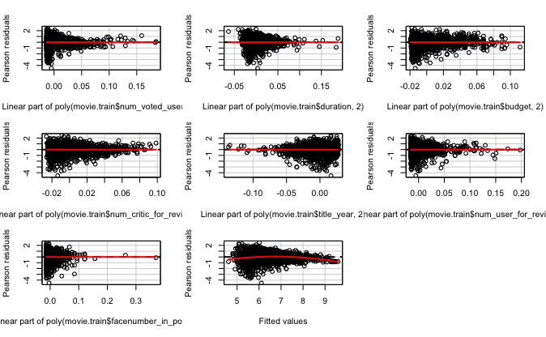

```r
residualPlots(lm.fit2)
```

For convinience to interpret the result, I will start with Full3(additive mode with interactiin terms). After checking residual, then decide should we add higher order terms.

Split data into Test and Train:

```r
set.seed(234) # 234(0.4456)
indx = sample(1:nrow(movie.sig), as.integer(0.9*nrow(movie.sig)))
indx # ramdomize rows, save 90% of data into index

movie_train = movie.sig[indx,]
movie_test = movie.sig[-indx,]
```

```r
# lm.fit 1: linear model with interaction term dropping insig predictors.
# insig terms: director facebooklike','movie fb like' and 'cast total fb likes' from summary(full3)
# Note: nothing to do with step function we choose for full3.
lm.fit1<-lm(movie_train$imdb_score~movie_train$num_voted_users+movie_train$num_critic_for_reviews+movie_train$num_user_for_reviews+movie_train$duration+movie_train$facenumber_in_poster+movie_train$gross+movie_train$budget+movie_train$title_year+factor(movie_train$genres)+movie_train$duration*movie_train$num_voted_users+movie_train$num_voted_users*movie_train$num_user_for_reviews+movie_train$gross*movie_train$budget)
summary(lm.fit1)
```

Do Lack of fit test to see if removing the predictors improve model performance:

```r
#lm.full: full linear model with interaction terms on train dataset.
lm.full<-lm(movie_train$imdb_score~movie_train$num_voted_users+movie_train$num_critic_for_reviews+movie_train$num_user_for_reviews+movie_train$duration+movie_train$facenumber_in_poster+movie_train$gross+movie_train$movie_facebook_likes+movie_train$director_facebook_likes+movie_train$cast_total_facebook_likes+movie_train$budget+movie_train$title_year+factor(movie_train$genres)+movie_train$duration*movie_train$num_voted_users+movie_train$num_voted_users*movie_train$num_user_for_reviews+movie_train$gross*movie_train$budget)
```

```r
anova(lm.full,lm.fit1) # H0: reduced model fits===lack of fit=0
```

Diagnostics:

```r
plot(lm.fit1)
# residual vs fitted indicates might be higher order term. Normal plot not good.
```

```r
library(car)
residualPlots(lm.fit1)
```

Mots of the residual vs predictor plots have a general trend of curviture, which indicates the current model does not fit. Higher order terms should be included.

Fit model with higer order terms:

```r
# lm.fit2: model based on lm.fit1 adding higer order for all variables except for 'face number in poster' and 'title-year'.
lm.fit2<-lm(movie_train$imdb_score~poly(movie_train$num_voted_users,2)+poly(movie_train$num_critic_for_reviews,2)+poly(movie_train$num_user_for_reviews,2)+poly(movie_train$duration,2)+movie_train$facenumber_in_poster+poly(movie_train$gross,2)+poly(movie_train$budget,2)+movie_train$title_year+factor(movie_train$genres)+movie_train$duration*movie_train$num_voted_users+movie_train$num_voted_users*movie_train$num_user_for_reviews+movie_train$gross*movie_train$budget)
summary(lm.fit2)
```

```r
anova(lm.fit1, lm.fit2)
```

```r
# lm.fit3: based on lm.fit2 dropping second order term for 'num_user_for_review','gross' and budget*gross
lm.fit3<-lm(movie_train$imdb_score~poly(movie_train$num_voted_users,2)+poly(movie_train$num_critic_for_reviews,2)+movie_train$num_user_for_reviews+poly(movie_train$duration,2)+movie_train$facenumber_in_poster+movie_train$gross+poly(movie_train$budget,2)+movie_train$title_year+factor(movie_train$genres)+movie_train$duration*movie_train$num_voted_users+movie_train$num_voted_users*movie_train$num_user_for_reviews)
summary(lm.fit3)
```

Gross not sig,drop

```r
anova(lm.fit2,lm.fit3)
```

Diagnostics for lm.fit2:

```r
plot(lm.fit2)
```

```r
library(car)
residualPlots(lm.fit2)
```

```r
# lm.fit4: based on lm.fit2 addting second order for title year.
lm.fit4<-lm(movie_train$imdb_score~poly(movie_train$num_voted_users,2)+poly(movie_train$num_critic_for_reviews,2)+poly(movie_train$num_user_for_reviews,2)+poly(movie_train$duration,2)+movie_train$facenumber_in_poster+poly(movie_train$gross,2)+poly(movie_train$budget,2)+poly(movie_train$title_year,2)+factor(movie_train$genres)+movie_train$duration*movie_train$num_voted_users+movie_train$num_voted_users*movie_train$num_user_for_reviews+movie_train$gross*movie_train$budget)
summary(lm.fit4)
```

```r
anova(lm.fit2,lm.fit4)
```

```r
AIC(lm.fit2)
AIC(lm.fit4)
```

Marginal Model plot:

```r
library(car)
marginalModelPlots(lm.fit2)
```

Check for residual ourliers:

```r
library(car)
qqPlot(lm.fit2$residuals,id.n = 10)
```

```r
library(car)
outlierTest(lm.fit2) # H0: residual is not an outlier
```

Before we drop, let’s do some digsnostics to double check which to drop.

```r
library(car)
influencePlot(lm.fit2, id.n=10)
```

```r
# lm.fit5: model based on lm.fit4 removing 10 outliers.
movie_train<-movie_train[-c(509,425,17,1443,2559,1222,1200,165,1418,139),]

lm.fit5<-lm(movie_train$imdb_score~poly(movie_train$num_voted_users,2)+poly(movie_train$num_critic_for_reviews,2)+poly(movie_train$num_user_for_reviews,2)+poly(movie_train$duration,2)+movie_train$facenumber_in_poster+poly(movie_train$gross,2)+poly(movie_train$budget,2)+movie_train$title_year+factor(movie_train$genres)+movie_train$duration*movie_train$num_voted_users+movie_train$num_voted_users*movie_train$num_user_for_reviews+movie_train$gross*movie_train$budget)
summary(lm.fit5)
```

```r
compareCoefs(lm.fit2, lm.fit5)
```

Diagnostics for lm.fit5:

```r
library(car)
residualPlots(lm.fit5)
```

```r
plot(lm.fit5)
```

Now,let’s look at model assumption for both lm.fit2 and lm.fit5:

```r
# normality
shapiro.test(lm.fit2$residuals)
shapiro.test(lm.fit5$residuals)
```

```r
# equal variance : H0: variance is not constant
ncvTest(lm.fit2)
ncvTest(lm.fit5)
```

This is just to explore more interesting facts Plots for data with fitted regression line:

```r
library(ggplot2)
ggplot(data=movie_train,aes(x=duration,y=imdb_score,colour=factor(genres)))+stat_smooth(method=lm,fullrange = FALSE)+geom_point()
```

```r
library(ggplot2)
ggplot(data=movie_train,aes(x=num_voted_users,y=imdb_score,colour=factor(genres)))+stat_smooth(method=lm,fullrange = FALSE)+geom_point()
```

```r
library(ggplot2)
ggplot(data=movie_train,aes(x=facenumber_in_poster,y=imdb_score,colour=factor(genres)))+stat_smooth(method=lm,fullrange = FALSE)+geom_point()
```

```r
library(ggplot2)
ggplot(data=movie_train,aes(x=gross,y=imdb_score,colour=factor(genres)))+stat_smooth(method=lm,fullrange = FALSE)+geom_point()
```

```r
library(ggplot2)
ggplot(data=movie_train,aes(x=budget,y=imdb_score,colour=factor(genres)))+stat_smooth(method=lm,fullrange = FALSE)+geom_point()
```

## Step 4: Making predictions on the test dataset

Rewriting model lm.fit5 in another notation: # Note, if write in lm(train$score~train$x1+train$x2….), it will create the same number of values with the train data set when predict().

```r
# lm.fit6 =lm.fit 2 using difference writing
lm.fit6<-lm(imdb_score~poly(num_voted_users,2)+poly(num_critic_for_reviews,2)+poly(num_user_for_reviews,2)+poly(duration,2)+facenumber_in_poster+poly(gross,2)+poly(budget,2)+title_year+factor(genres)+duration*num_voted_users+num_voted_users*num_user_for_reviews+gross*budget,data=data.frame(movie_train))
summary(lm.fit6)
```

```r
pr<-predict.lm(lm.fit6,newdata = data.frame(movie_test),interval = 'confidence')
pr[1:20,]
```

Check Accuracy: Mean Absolute Error: how far, on average, prediction is from the true value.

```r
MAE <- function(actual, predicted) {
mean(abs(actual - predicted))
}
MAE(pr, movie_test$imdb_score)
```

Checking the impact significance of predictors on IMDB score.

```r
# stantdardized regression coefficients
library(QuantPsyc)
lm.beta(lm.fit6)
```